# Master Thesis

- Show All Code
- Hide All Code
- View Source

Author

Caroline Müller

Published

May 14, 2026

# 1 Codebook & Research Questions

## 1.1 Research Questions

RQ2: Using AI surrogates, how does the amount of textual information affect between-surrogate variability in LLM scores and their correspondence with questionnaire scores?

- RQ2a (Between-Surrogate Variability): To what extent do text length and number of texts affect between-surrogate variability (SD) in LLM scores per basic need satisfaction dimension?
- RQ2b (Correspondence): To what extent do text length and number of texts affect the magnitude of correlations between LLM scores and questionnaire scores per basic need satisfaction dimension?

RQ3: To what extent do AI surrogate outputs resemble those of human participants in terms of textual properties, score distributions, and LLM–questionnaire correspondence?

- RQ3a (Distributional Equivalence): To what extent do distributional properties (mean, SD) of LLM scores differ between AI surrogate and human participant data?
- RQ3b (Correspondence): To what extent do correlations between LLM scores and questionnaire scores per basic need satisfaction differ between AI surrogate and human participant data?

## 1.2 Code Book

- id: participant id
- id_type: participant type, values “AI” or “HU”
- llm_aut_mean | Mean LLM-scored Autonomy across 3 repeated prompts, based on text. | Numeric | 1 (Low) to 5 (High) |
- llm_com_mean | Mean LLM-scored Competence across 3 repeated prompts, based on text. | Numeric | 1 (Low) to 5 (High) |
- llm_rel_mean | Mean LLM-scored Relatedness across 3 repeated prompts, based on text. | Numeric | 1 (Low) to 5 (High) |
- q_aut_mean | Mean of 4 items measuring self-reported Autonomy need satisfaction | Numeric | 1 (Low) to 5 (High) |
- q_com_mean | Mean of 4 items measuring self-reported Competence need satisfaction | Numeric | 1 (Low) to 5 (High) |
- q_rel_mean | Mean of 4 (humans: 5) items measuring self-reported Relatedness need satisfaction | Numeric | 1 (Low) to 5 (High) |
- actual_words

# 2 Preparation (cleaning, libraries, global variables)

2.1 Software Environment

The analysis is conducted using the tidyverse framework for data manipulation and the psych and performance packages for psychometric validation. Tables are rendered according to APA 7th edition standards using flextable and rempsyc.

```r
#| label: setup-environment
#| include: false
#| warning: false

# 1. Clean environment ---------------------------------------------------------
graphics.off()

# 2. Load libraries ------------------------------------------------------------
# Note: suppressPackageStartupMessages hides the "attach" noise from the console
suppressPackageStartupMessages({
  library(dplyr)
  library(ggplot2)
  library(tidyr)
  library(flextable)
  library(rempsyc)
  library(scales)
  library(psych)
  library(performance)
  library(officer)
  library(paletteer)
  library(janitor)
  library(extrafont)
  library(car)          # leveneTest for variance equality tests
  library(boot)         # boot() for bootstrapped CIs
  library(ggridges)     # ridgeline plots

})
# 3. Set seed for bootstrap CIs ------------------------------------------------
set.seed(2026)

# 4. Message output ------------------------------------------------------------
message("Environment cleaned and libraries loaded successfully.")
```

```
Environment cleaned and libraries loaded successfully.
```

2.2 Global Study Parameters

```r
#| label: study-parameters

# Target sample was calculated using a simulation
TARGET_SAMPLE <- 400

# Bootstrap iterations — set low for development runs
# TODO before submission: raise to 5000+ (RQ2 uses 10000 for consistency)
BOOTSTRAP_SAMPLES <- 10000
if (BOOTSTRAP_SAMPLES < 1000) warning(
  "BOOTSTRAP_SAMPLES is low (", BOOTSTRAP_SAMPLES, "). Raise before final render."
)


# Font and colors
THESIS_FONT <- "Calibri"
THESIS_FONTSIZE <- 11
THESIS_PALETTE <- "nationalparkcolors::Acadia"

# Define custom palettes
COLOR_AI <- c("Autonomy" = "#084594", "Competence" = "#4292c6", "Relatedness" = "#9ecae1")
COLOR_HU <- c("Autonomy" = "#800026", "Competence" = "#e31a1c", "Relatedness" = "#fcbba1")

# Combine for scale_fill_manual
COLORS <- c(COLOR_HU, COLOR_AI)


# not yet used
COL_AI_SINGLE = "#1F5A71"
COL_HU_SINGLE = "#BE2A16"
COL_NEUTRAL_SINGLE = "#B3B3B3"
COL_GRID = "#E6E6E6"
COL_LBL_INSIDE = "#FFFFFF"
COL_LBL_OUTSIDE = "#B3B3B3"# ?


COL_DIFF = "#DDA613"
#COL_AI_SHADES = c("#0A5D83", "#2085AB", "#489CC1", "#6DBCE0", "#87D3ED")
#USED:
COL_AI_SHADES = c("#1F5A71", "#2085AB", "#489CC1", "#6DBCE0", "#9ecae1","#FFFFFF")
COL_HU_SHADES = c("#BE2A16", "#CE5545", "#DC7D71", "#E9A39B", "#F5C9C5","#FFFFFF")

COL_AI_SHADES2 = c("#98A33E", "#B2BB61", "#CCD485", "#E6ECA9", "#F3F6D4","#FFFFFF")


COL_AI_LINE = COL_AI_SHADES[1]
COL_HU_LINE = COL_HU_SHADES[1]

COL_AI_LLM = COL_AI_SHADES[1]
COL_AI_Q = COL_AI_SHADES2[1]

# 4. AI surrogates colors  -----------------------------------------------------

# used as shades for the 3 text lengths
COL_AI_TEXTS = c("1" = COL_AI_SHADES[4], "3" = COL_AI_SHADES[2], "5" = COL_AI_SHADES[1])

# used as shades for the 3 target word lengths
COL_AI_WORDS = c("50" = COL_AI_SHADES[4], "150" = COL_AI_SHADES[2], "300" = COL_AI_SHADES[1])

# 5. LABELS --------------------------------------------------------------------

# Labels for the basic psychological needs
AUT <- "autonomy"
COM <- "competence"
REL <- "relatedness"

TABLE_LABEL_AUT <- "Autonomy"
TABLE_LABEL_COM <- "Competence"
TABLE_LABEL_REL <- "Relatedness"
#NEEDS <- c(TABLE_LABEL_AUT, TABLE_LABEL_COM, TABLE_LABEL_REL)
#ITEMS <- paste0(rep(NEEDS, each = 4), " ", 1:4) # Generate the labels

# Labels for LLM vs Questionnaire comparison
LABEL_WORDC      <- "Word Count (LLM)"
LABEL_NEEDS <- paste("Need Dimension")
LABEL_LLM_AUT <- paste("LLM", TABLE_LABEL_AUT)
LABEL_LLM_COM <- paste("LLM", TABLE_LABEL_COM)
LABEL_LLM_REL <- paste("LLM", TABLE_LABEL_REL)
LABEL_Q_AUT   <- paste("Questionnaire", TABLE_LABEL_AUT)
LABEL_Q_COM   <- paste("Questionnaire", TABLE_LABEL_COM)
LABEL_Q_REL   <- paste("Questionnaire", TABLE_LABEL_REL)

# Labels for samples
LABEL_SAMPLE <- "Sample"
LABEL_AI <- "AI surrogates"
LABEL_HU <- "Humans"

# Confidence interval level
CI_LEVEL <- .95
CI_LABEL <- paste0(CI_LEVEL * 100, "% CI")
```

2.3 Helper functions

For APA7 styling.

```r
#| label: helper-functions
#| include: false

# Define a standard APA 7 style for this thesis --------------------------------
style_apa7 <- function(x) {
  x |>
    font(fontname = THESIS_FONT, part = "all") |>
    fontsize(size = THESIS_FONTSIZE, part = "all") |>
    valign(valign = "top", part = "body") |>
    set_table_properties(layout = "autofit")
}

# Generic APA note helper (refined for internal use) ---------------------------
add_apa_note <- function(x, note_text) {
  x |>
    add_footer_lines("") |>
    mk_par(
      part = "footer", i = 1, j = 1,
      value = as_paragraph(
        as_chunk("Note. ", props = fp_text_default(italic = TRUE,
                                                   font.family = THESIS_FONT,
                                                   font.size = THESIS_FONTSIZE)),
        as_chunk(note_text, props = fp_text_default(italic = FALSE,
                                                    font.family = THESIS_FONT,
                                                    font.size = THESIS_FONTSIZE))
      )
    )
}
```

# 3 Prep Data

## 3.1 Import human data

```r
# 1. Setup Paths and Import ----------------------------------------------------
data_path_human <- "../10_data/10_raw/humans_2026-04-13.csv"

d_human_raw <- read.csv(data_path_human, sep = "|", na.strings = "NA")



message("Data loaded: ", basename(data_path_human), " | Modified: ",
        format(file.mtime(data_path_human), "%Y-%m-%d %H:%M"))
```

```
Data loaded: humans_2026-04-13.csv | Modified: 2026-04-13 09:08
```

```r
# 2. Rename and Clean ----------------------------------------------------------
# All columns named explicitly — any upstream rename breaks loudly here.




colSums(is.na(d_human_raw))
```

```
participant_id         gender      birthyear      education           aut1
             0              0              0              0              0
          aut2           aut3           aut4          comp1          comp2
             0              0              0              0              0
         comp3          comp4           rel1           rel2           rel3
             0              0              0              0              0
          rel4           rel5        PVQ_M_1        PVQ_M_2        PVQ_M_3
             0              0             72             72             72
       PVQ_M_4        PVQ_M_5        PVQ_M_6        PVQ_M_7        PVQ_M_8
            72             72             72             72             72
       PVQ_M_9       PVQ_M_10       PVQ_M_11       PVQ_M_12       PVQ_M_13
            72             72             72             72             72
      PVQ_M_14       PVQ_M_15       PVQ_M_16       PVQ_M_17       PVQ_M_18
            72             72             72             72             72
      PVQ_M_19       PVQ_M_20       PVQ_M_21        PVQ_K_1        PVQ_K_2
            72             72             72             60             60
       PVQ_K_3        PVQ_K_4        PVQ_K_5        PVQ_K_6        PVQ_K_7
            60             60             60             60             60
       PVQ_K_8        PVQ_K_9       PVQ_K_10       PVQ_K_11       PVQ_K_12
            60             60             60             60             60
      PVQ_K_13       PVQ_K_14       PVQ_K_15       PVQ_K_16       PVQ_K_17
            60             60             60             60             60
      PVQ_K_18       PVQ_K_19       PVQ_K_20       PVQ_K_21   llm_aut_rep1
            60             60             60             60              0
  llm_aut_rep2   llm_aut_rep3   llm_com_rep1   llm_com_rep2   llm_com_rep3
             0              0              0              0              0
  llm_rel_rep1   llm_rel_rep2   llm_rel_rep3      wc_text_1      wc_text_2
             0              0              0              0              0
     wc_text_3       wc_total
             0              0
```

```r
d_human <- d_human_raw |>
  rename(
    # Demographics
    id             = participant_id,
    gender         = gender,
    age_year       = birthyear,
    edu_level      = education,

    # SDT Self-Report Items
    aut_1 = aut1, aut_2 = aut2, aut_3 = aut3, aut_4 = aut4,
    com_1 = comp1, com_2 = comp2, com_3 = comp3, com_4 = comp4,
    rel_1 = rel1, rel_2 = rel2, rel_3 = rel3, rel_4 = rel4, rel_5 = rel5,

    # LLM Ratings (Validation Targets)
    llm_aut_1 = llm_aut_rep1, llm_aut_2 = llm_aut_rep2, llm_aut_3 = llm_aut_rep3,
    llm_com_1 = llm_com_rep1, llm_com_2 = llm_com_rep2, llm_com_3 = llm_com_rep3,
    llm_rel_1 = llm_rel_rep1, llm_rel_2 = llm_rel_rep2, llm_rel_3 = llm_rel_rep3,

    # word count
    actual_words = wc_total
  ) |>
  # Drop PVQ items before type conversion to save memory/processing
  select(-starts_with("PVQ")) |>
  mutate(
    across(c(id, gender, edu_level), as.factor),
    age_year = as.integer(age_year),
    across(starts_with("aut_"), as.numeric),
    across(starts_with("com_"), as.numeric),
    across(starts_with("rel_"), as.numeric),
    across(starts_with("llm_"), as.numeric)
  ) |>
  # Compute means and reshape to match d_ai structure
  mutate(
    llm_aut_mean = rowMeans(across(c(llm_aut_1, llm_aut_2, llm_aut_3)), na.rm = TRUE),
    llm_com_mean = rowMeans(across(c(llm_com_1, llm_com_2, llm_com_3)), na.rm = TRUE),
    llm_rel_mean = rowMeans(across(c(llm_rel_1, llm_rel_2, llm_rel_3)), na.rm = TRUE),
    q_aut_mean   = rowMeans(across(c(aut_1, aut_2, aut_3, aut_4)),       na.rm = TRUE),
    q_com_mean   = rowMeans(across(c(com_1, com_2, com_3, com_4)),       na.rm = TRUE),
    q_rel_mean   = rowMeans(across(c(rel_1, rel_2, rel_3, rel_4, rel_5)), na.rm = TRUE),
    id_type      = "HU",
    actual_words = as.integer(actual_words)
  ) |>
  select(id, id_type, llm_aut_mean, llm_com_mean, llm_rel_mean,
         q_aut_mean, q_com_mean, q_rel_mean, actual_words)
```

## 3.2 Import AI data

```r
#| label: import-validation
#| message: false


# 1. Setup Paths and Import ----------------------------------------------------
data_path_ai <- "../10_data/80_analyses_exports/d_rq3_ai.rds"

d_ai_raw <- readRDS(data_path_ai)


# 2. Rename and Clean ----------------------------------------------------------
d_ai <- d_ai_raw |>
  rename(
    id = id,
    id_type = id_type,
    llm_aut_mean = llm_aut_mean,
    llm_com_mean = llm_com_mean,
    llm_rel_mean = llm_rel_mean,
    q_aut_mean = q_aut_mean,
    q_com_mean = q_com_mean,
    q_rel_mean = q_rel_mean,
    actual_words = actual_words,
    condition = condition,
    text_count = text_count,
    target_words = target_words
  ) |>
  mutate(
    actual_words = as.integer(actual_words),
    llm_aut_mean = as.numeric(llm_aut_mean),
    llm_com_mean = as.numeric(llm_com_mean),
    llm_rel_mean = as.numeric(llm_rel_mean),
    q_aut_mean = as.numeric(q_aut_mean),
    q_com_mean = as.numeric(q_com_mean),
    q_rel_mean = as.numeric(q_rel_mean),
    condition = as.factor(condition),
    target_words = as.integer(target_words),
    text_count   = as.integer(text_count)

  ) |>
  select(id, id_type, llm_aut_mean, llm_com_mean, llm_rel_mean,
         q_aut_mean, q_com_mean, q_rel_mean, actual_words)


# 3. Structural Integrity Check ------------------------------------------------

# Ensure all variables required for subsequent analyses are present
required_vars <- c("id", "id_type",
                   "llm_aut_mean", "llm_com_mean", "llm_rel_mean",
                   "q_aut_mean",   "q_com_mean",   "q_rel_mean",
                   "actual_words")
missing_vars  <- setdiff(required_vars, names(d_ai))

if (length(missing_vars) > 0) {
  stop(paste("CRITICAL: Missing columns:", paste(missing_vars, collapse = ", ")))
}
```

## 3.4 Quick integrity check

```r
#| label: audit-check-ai
#| message: false

# Audit Summary -------------------------------------------------------------
tbl_import_audit_ai <- tibble::tribble(
  ~Metric,                ~Value,
  "Source File",          basename(data_path_ai),
  "Dataframe",            as.character(deparse(substitute(d_ai))),
  "Total Rows",           as.character(nrow(d_ai)),
  "Distinct Personas",    as.character(dplyr::n_distinct(d_ai$id)),
  "Columns",              as.character(ncol(d_ai))
)

tbl_import_audit_ai
```

```
# A tibble: 5 × 2
  Metric            Value
  <chr>             <chr>
1 Source File       d_rq3_ai.rds
2 Dataframe         d_ai
3 Total Rows        394
4 Distinct Personas 394
5 Columns           9
```

```r
# Audit Summary -------------------------------------------------------------
tbl_import_audit_human <- tibble::tribble(
  ~Metric,                 ~Value,
  "Source File",           data_path_human,
  "Dataframe",             as.character(deparse(substitute(d_human))),
  "Total Rows",            as.character(nrow(d_human)),
  "Distinct Participants", as.character(dplyr::n_distinct(d_human$id)),
  "Columns",               as.character(ncol(d_human))
)

tbl_import_audit_human
```

```
# A tibble: 5 × 2
  Metric                Value
  <chr>                 <chr>
1 Source File           ../10_data/10_raw/humans_2026-04-13.csv
2 Dataframe             d_human
3 Total Rows            132
4 Distinct Participants 132
5 Columns               9
```

```r
#| label: import-debug
#| include: false
#| message: false

# looking at the "fresh" state of d before any column mutations

message("--- START DEBUG LOG: Section 3.1 ---")
```

```
--- START DEBUG LOG: Section 3.1 ---
```

```r
message("Columns AI:     ", ncol(d_ai))
```

```
Columns AI:     9
```

```r
message("Columns Humans:     ", ncol(d_human))
```

```
Columns Humans:     9
```

```r
# 1. Structural Inspection -----------------------------------------------------
#glimpse(d)

# 2. Integrity Check (Internal logic) -------------------------------------------
# Check for any immediate NAs in key variables
colSums(is.na(d_ai))
```

```
          id      id_type llm_aut_mean llm_com_mean llm_rel_mean   q_aut_mean
           0            0            0            0            0            0
  q_com_mean   q_rel_mean actual_words
           0            0            0
```

```r
colSums(is.na(d_human))
```

```
          id      id_type llm_aut_mean llm_com_mean llm_rel_mean   q_aut_mean
           0            0            0            0            0            0
  q_com_mean   q_rel_mean actual_words
           0            0            0
```

```r
# 3. Clean-up verification umns ------------------------------------------------
message("--- END DEBUG LOG: Section 3.1 ---")
```

```
--- END DEBUG LOG: Section 3.1 ---
```

## 3.5 Merge AI and Human data

## 3.6 Matched Condition Verification

Table 1: Total Word Count Summary by Sample

| Sample | N | Actual word count summary M | Actual word count summary SD | Actual word count summary Mdn | Actual word count summary Min | Actual word count summary Max |
| --- | --- | --- | --- | --- | --- | --- |
| AI surrogates | 394 | 152.11 | 6.18 | 153.0 | 128 | 166 |
| Humans | 132 | 184.76 | 57.45 | 165.5 | 131 | 506 |

Note. Actual words are the total word count across 3 scored texts for both samples. For AI surrogates, short-3 is the matched condition.

# 4 Descriptives: Table

Descriptive statistics per need dimension and score type (LLM-scored vs. questionnaire-based), reported separately for AI surrogates and human participants. All variables are on a 1–5 scale.

Table 2: Descriptive Statistics for LLM Scores and Questionnaire Scores by Need Dimension and Group (AI Surrogates vs. Human Participants)

| Need | Score Type | Sample | M (SD) | Mdn | Min | Max |
| --- | --- | --- | --- | --- | --- | --- |
| Autonomy | LLM Score | AI surrogates | 2.94 (0.40) | 3.00 | 2.00 | 4.67 |
|  |  | Humans | 2.66 (0.64) | 3.00 | 2.00 | 4.67 |
|  | Questionnaire Score | AI surrogates | 3.24 (0.49) | 3.25 | 2.00 | 4.50 |
|  |  | Humans | 3.61 (0.71) | 3.50 | 1.00 | 5.00 |
| Competence | LLM Score | AI surrogates | 3.41 (0.47) | 3.00 | 2.33 | 4.67 |
|  |  | Humans | 2.58 (0.55) | 3.00 | 1.00 | 4.00 |
|  | Questionnaire Score | AI surrogates | 4.19 (0.34) | 4.00 | 3.25 | 5.00 |
|  |  | Humans | 3.75 (0.72) | 3.75 | 1.25 | 5.00 |
| Relatedness | LLM Score | AI surrogates | 3.07 (0.40) | 3.00 | 2.00 | 4.00 |
|  |  | Humans | 3.42 (0.54) | 3.00 | 2.00 | 5.00 |
|  | Questionnaire Score | AI surrogates | 3.86 (0.42) | 4.00 | 2.25 | 5.00 |
|  |  | Humans | 3.62 (0.74) | 3.60 | 1.00 | 5.00 |

Table 3: Descriptive Statistics for LLM Scores and Questionnaire Scores by Need Dimension and Group (M (SD))

| Need Dimension | Instrument | Humans M (SD) | AI surrogates M (SD) | Difference Δ M (Δ SD) |
| --- | --- | --- | --- | --- |
| Autonomy | LLM Score | 2.66 (0.64) | 2.94 (0.40) | 0.27 (-0.24) |
|  | Questionnaire Score | 3.61 (0.71) | 3.24 (0.49) | -0.37 (-0.22) |
| Competence | LLM Score | 2.58 (0.55) | 3.41 (0.47) | 0.82 (-0.08) |
|  | Questionnaire Score | 3.75 (0.72) | 4.19 (0.34) | 0.45 (-0.38) |
| Relatedness | LLM Score | 3.42 (0.54) | 3.07 (0.40) | -0.35 (-0.14) |
|  | Questionnaire Score | 3.62 (0.74) | 3.86 (0.42) | 0.24 (-0.32) |

Note. Values are M (SD). All scores on a 1–5 scale. LLM = mean of 3 scoring repeats; Questionnaire = mean of 4–5 items. Δ = AI surrogates − Humans. AI surrogates N = 394; Humans N = 132.

Table 4: Descriptive Statistics for LLM Scores and Questionnaire Scores by Need Dimension and Group (IQR and Range)

| Need Dimension | Score Type | IQR Humans | IQR AI surrogates | Range Humans | Range AI surrogates |
| --- | --- | --- | --- | --- | --- |
| Autonomy | LLM Score | 1.00 | 0.00 | 2.67 | 2.67 |
|  | Questionnaire Score | 1.00 | 0.50 | 4.00 | 2.50 |
| Competence | LLM Score | 1.00 | 1.00 | 3.00 | 2.33 |
|  | Questionnaire Score | 0.81 | 0.50 | 3.75 | 1.75 |
| Relatedness | LLM Score | 1.00 | 0.00 | 3.00 | 2.00 |
|  | Questionnaire Score | 0.80 | 0.25 | 4.00 | 2.75 |

Note. IQR = interquartile range (Q3 − Q1). Range = maximum − minimum. All scores on a 1–5 scale. AI surrogates N = 394; Humans N = 132.

### Kurtosis, Skewness

Interpretation Kurtosis - Excess kurtosis near 0: roughly normal tail behavior - Positive excess kurtosis: more outlier-prone, heavier tails - Negative excess kurtosis: flatter / lighter-tailed / more bounded

Interpretation Skewness - Around 0: little asymmetry - Larger positive values: increasing right-tail pull; the mean is often above the median - Larger negative values: increasing left-tail pull; the mean is often below the median

Table 5: Distribution Statistics for LLM Scores and Questionnaire Scores by Need Dimension and Group (Quantiles, IQR, Skewness, Kurtosis)

| Need Dimension | Instrument | Humans Q1 | Humans Q3 | Humans IQR | Humans Skewness | Humans Kurtosis | AI surrogates Q1 | AI surrogates Q3 | AI surrogates IQR | AI surrogates Skewness | AI surrogates Kurtosis |
| --- | --- | --- | --- | --- | --- | --- | --- | --- | --- | --- | --- |
| Autonomy | LLM Score | 2.00 | 3.00 | 1.00 | 0.60 | -0.30 | 3.00 | 3.0 | 0.00 | -0.25 | 2.84 |
|  | Questionnaire Score | 3.00 | 4.00 | 1.00 | -0.22 | 0.47 | 3.00 | 3.5 | 0.50 | 0.00 | -0.30 |
| Competence | LLM Score | 2.00 | 3.00 | 1.00 | 0.00 | -0.69 | 3.00 | 4.0 | 1.00 | 0.36 | -1.60 |
|  | Questionnaire Score | 3.44 | 4.25 | 0.81 | -0.74 | 0.88 | 4.00 | 4.5 | 0.50 | 0.32 | -0.52 |
| Relatedness | LLM Score | 3.00 | 4.00 | 1.00 | 0.01 | -0.65 | 3.00 | 3.0 | 0.00 | 0.37 | 2.35 |
|  | Questionnaire Score | 3.20 | 4.00 | 0.80 | -0.32 | 0.41 | 3.75 | 4.0 | 0.25 | -0.30 | 2.21 |

Note. All scores on a 1–5 scale. Q1 = 25th percentile; Q3 = 75th percentile; IQR = interquartile range (Q3 − Q1); Skewness = Fisher's moment coefficient (g1); Kurtosis = excess kurtosis (g2). AI surrogates N = 394; Humans N = 132.

### Correlations

Table 6: Pearson Correlations Between LLM and Questionnaire Scores by Need Dimension and Group

| Need | Humans | AI surrogates | Δr |
| --- | --- | --- | --- |
| Autonomy | 0.19 | 0.07 | -0.12 |
| Competence | 0.02 | 0.09 | 0.07 |
| Relatedness | -0.02 | 0.09 | 0.11 |

# 5 Descriptives: Plots

## Scatter plot - ggplot

Figure 1: Scatter plots of LLM mean scores (x-axis) against questionnaire composite scores (y-axis), faceted by need dimension (columns) and sample group (rows). Top row: AI surrogates; bottom row: human participants Each point represents one participant. Lines show OLS regression fits with 95% CIs. Pearson r values are shown per panel and correspond to those in the table above.

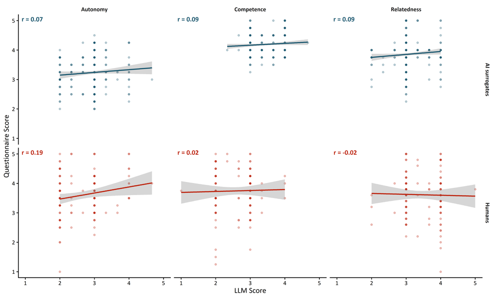

## Scatter plot - with jitter

Figure 2: Scatter plots of LLM mean scores (x-axis) against questionnaire composite scores (y-axis), faceted by need dimension (columns) and sample group (rows). Top row: AI surrogates; bottom row: human participants. Points are jittered to reveal density. Lines show OLS regression fits with 95% CIs. Pearson r values are shown per panel.

[figure not shown]

### five plot types

Five plot types in separate chunks for easy deletion/selection. Histograms (5.1) represent the bounded 1–5 integer scale — recommended for the thesis. Density plots (5.2) smooth the histogram but may show phantom tails outside 1–5. Violin + jitter (5.3) combines distribution shape with individual points. Boxplots (5.4) give a compact group comparison. Ridgeline plots (5.5) are well-suited for overlapping group comparisons. Note: with simulated human data, distributions appear artificially smooth.

## 5.1 Histograms

Figure 3: Score distributions by need dimension and group (AI surrogates vs. human participants). Vertical lines indicate group means. Rows: LLM scores (top) and questionnaire scores (bottom).

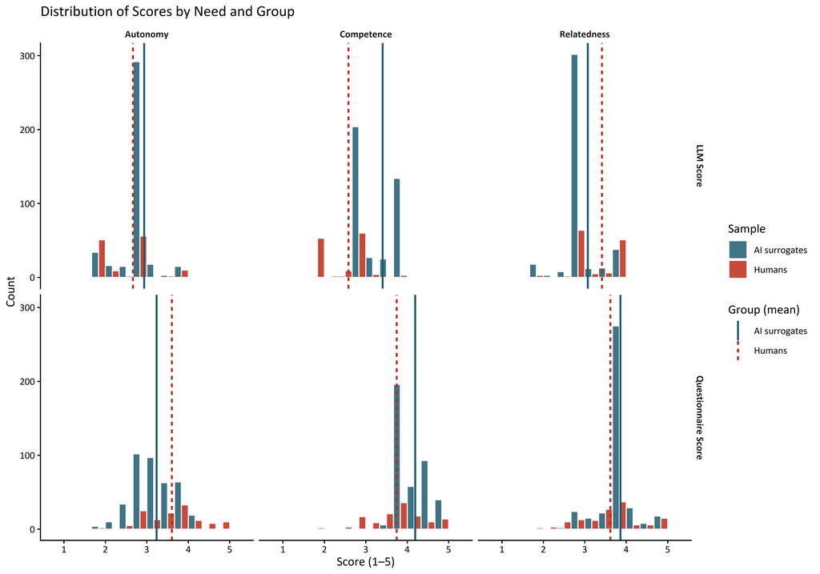

## 5.2 Density + Rug

Density curves smooth the histogram; they may show phantom tails outside 1–5. Rug marks (bottom) show individual observations — most useful for N < 200; at N ≥ 400 (AI group) tick marks overlap and histograms (5.1) are more informative.

Figure 4: Kernel density estimates of score distributions by need dimension and group. Rug marks indicate individual observations. Rows: LLM scores (top) and questionnaire scores (bottom).

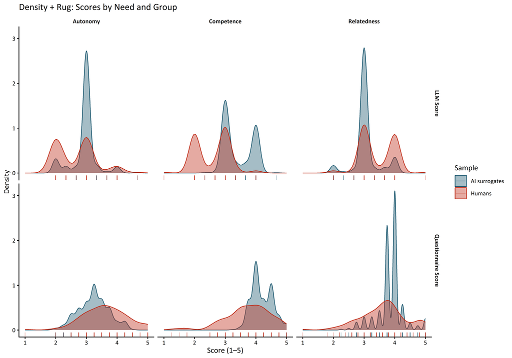

## 5.3 Violin + Jitter

Violin shows density shape; nested boxplot gives IQR; jitter shows individual observations.

Figure 5: Violin plots with nested boxplots and jittered observations for scores by need dimension and group. Width reflects density; boxes show IQR; center line shows median.

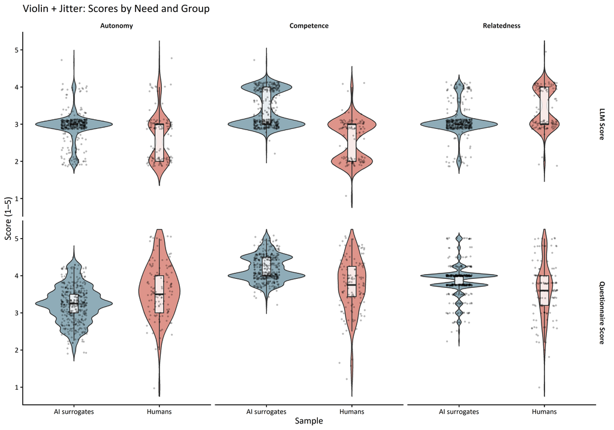

## 5.4 Boxplot + Jitter

On a 1–5 scale, outlier detection via IQR ± 1.5 is not applied — values at floor/ceiling are substantively meaningful, not measurement artifacts.

Figure 6: Boxplots with jittered individual observations for scores by need dimension and group. Whiskers extend to 1.5× IQR; floor/ceiling values are retained as substantively meaningful on a bounded scale.

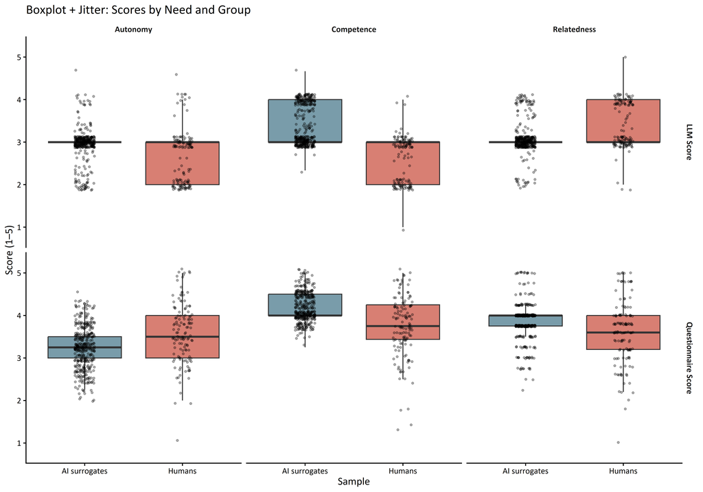

## 5.5 Ridgeline

Figure 7: Ridgeline density plots of scores by need dimension and group, facilitating direct overlap comparison between AI surrogates and human participants.

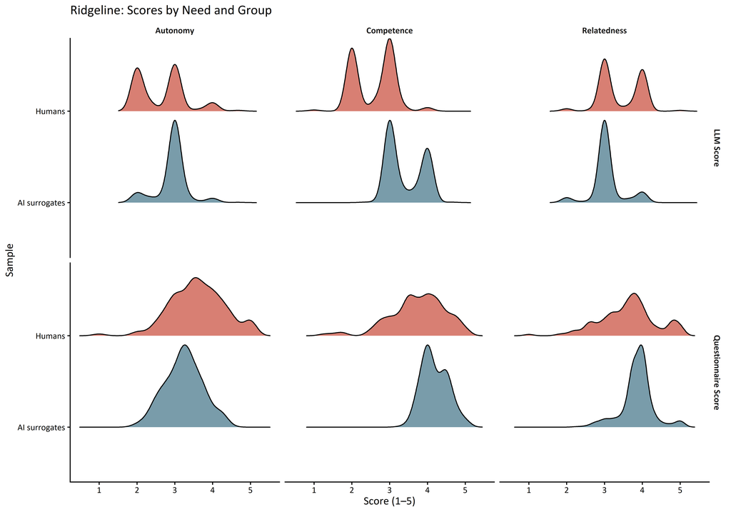

# 6 Test assumptions

Pearson correlations 1. Continuous (interval/ratio) variables 2. Linear relationship 3. Bivariate normality 4. Homoscedasticity 5. Paired, independent observations 6. No influential outliers

## 6.1 Normality Check (Q-Q Plots)

Q-Q plots compare the observed distribution to a theoretical normal distribution. Points on the diagonal indicate normality; S-curves indicate heavy tails; bends at extremes indicate floor/ceiling effects. Mild ceiling bends are expected on a 1–5 scale.

The t-test is robust to mild violations with N ≥ 30. Shapiro-Wilk results are stored in a hidden chunk for reference; with N_AI ≈ 400 the test is overpowered and a significant result may reflect trivially small deviations — Q-Q plots are the primary diagnostic.

Figure 8: Normal Q-Q plots for LLM scores by need dimension and group (RQ3a normality check). Points on the diagonal indicate normality; bends at extremes reflect the bounded 1–5 scale.

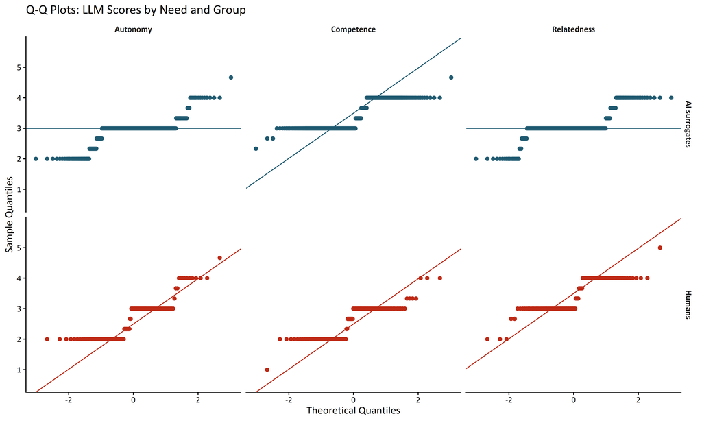

Alternative: z-scored QQ Plot

Figure 9: Normal Q-Q plots (z-scored) for LLM scores by need dimension and group (RQ3a normality check). Red line is the theoretical normal reference.

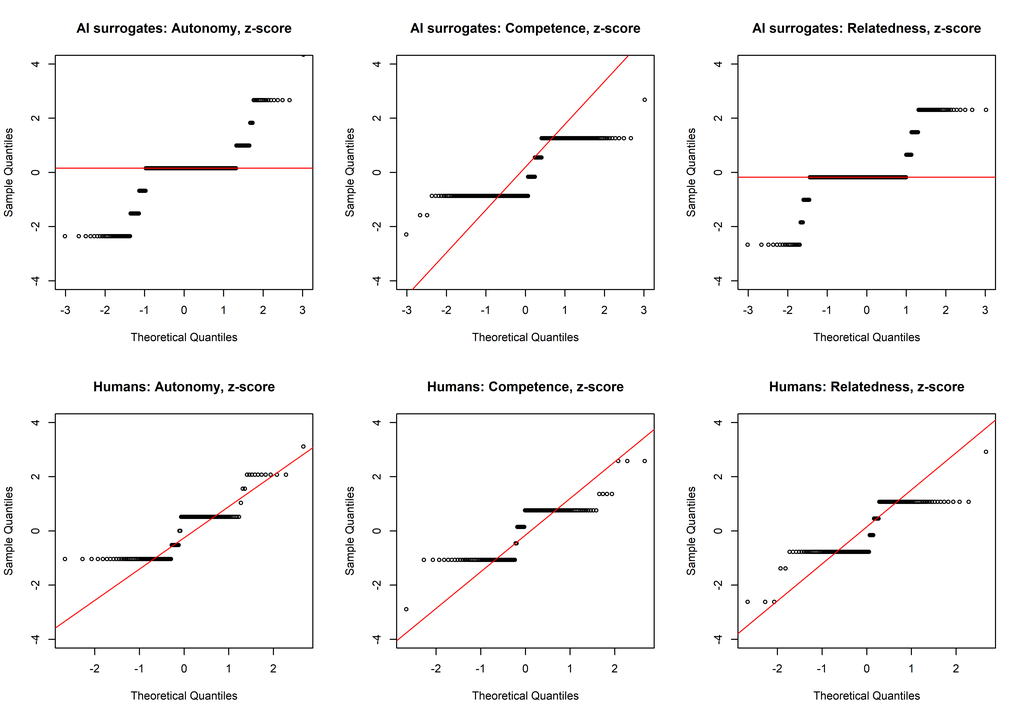

## 6.2 Normality Check correlations (Q-Q Plots)

For Pearson r to be valid, both variables should be approximately normally distributed within each group. With N_AI ≈ 400, mild violations are less consequential.

Figure 10: Normal Q-Q plots for LLM and questionnaire scores by need dimension and group (RQ3b normality check for Pearson correlation). Rows: AI surrogates and human participants × LLM/questionnaire score type.

[figure not shown]

## 6.3 Bivariate Normality Test (Mardia’s Test)

Pearson r requires that the *joint* distribution of (LLM score, questionnaire score) be approximately bivariate normal — univariate normality of each variable separately (sections 6.1–6.2) is necessary but not sufficient. Mardia’s test assesses bivariate normality via multivariate skewness and multivariate kurtosis; both statistics yield a p-value under the null of bivariate normality. The test is run separately for each group (AI surrogates, human participants) × need dimension combination, giving 6 tests total. With N_AI ≈ 400 the test is sensitive to small violations; Q-Q plots (section 6.2) and scatter plots (section 5) remain the primary visual diagnostic. Fisher’s z-transformation of Pearson r is asymptotically valid regardless of the marginal distributions, so modest violations are not disqualifying.

Table 7: Mardia’s Bivariate Normality Tests for LLM Score and Questionnaire Score Pairs by Need Dimension and Group (RQ3b Assumption Check)

| Need | Group | χ²(skew) | p (skew) | z(kurt) | p (kurt) |
| --- | --- | --- | --- | --- | --- |
| Autonomy | AI surrogates | 6.82 | 0.146 | 6.66 | < .001 |
|  | Humans | 12.43 | 0.014 | -0.19 | 0.850 |
| Competence | AI surrogates | 17.87 | 0.001 | -5.35 | < .001 |
|  | Humans | 15.13 | 0.004 | -0.28 | 0.781 |
| Relatedness | AI surrogates | 21.19 | < .001 | 10.92 | < .001 |
|  | Humans | 6.51 | 0.164 | -0.49 | 0.625 |

Note. Mardia’s test assesses bivariate normality of the (LLM score, questionnaire score) pair (Mardia 1970). χ²(skew) = multivariate skewness statistic; z(kurt) = multivariate kurtosis z-score. p < .05 indicates departure from bivariate normality. With N ≈ 400 (AI group), the test is sensitive to minor violations. Fisher’s z-transformation of Pearson r remains asymptotically valid under mild departures. AI surrogates N = 394; Humans N = 132.

Figure 11: Chi-square Q-Q plots of squared Mahalanobis distances for the (LLM score, questionnaire score) pair by need dimension and group (bivariate normality check). Under bivariate normality, distances follow a χ²(2) distribution and points should fall on the diagonal. Systematic upward curvature indicates heavy tails; downward curvature indicates light tails.

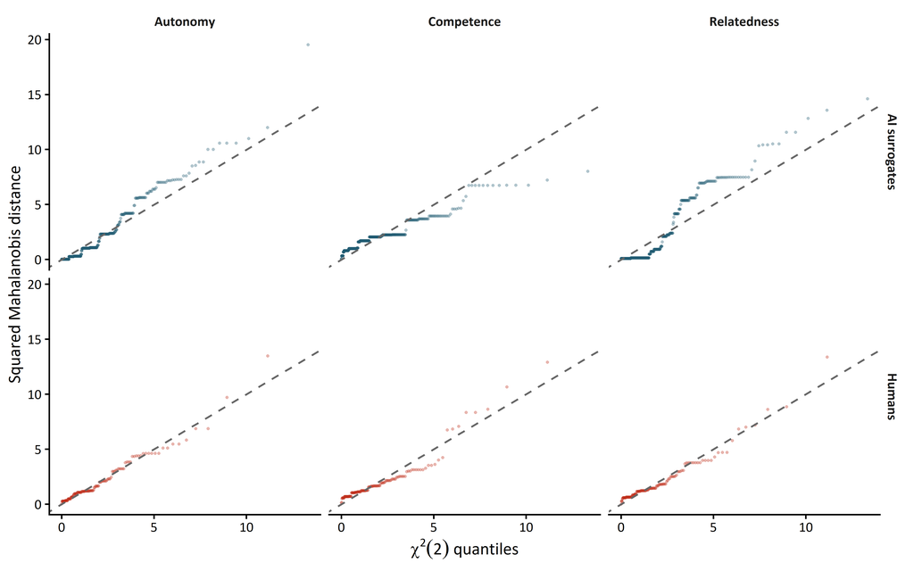

## 6.4 Linearity Check (LOESS vs. OLS)

The scatter plots below show LLM score (x) against questionnaire subscale score (y) for each group × need combination. The LOESS smoother (solid) and OLS fit (dashed) are overlaid; close agreement between the two lines supports the linearity assumption required for Pearson *r*. Points are jittered to reveal density at the integer-valued scores.

Figure 12: Scatter plots of LLM score (x-axis) vs. questionnaire subscale score (y-axis) by need dimension and group. Points are jittered to reveal density. Solid line = LOESS smoother; dashed line = OLS regression fit. Pearson r is shown per panel.

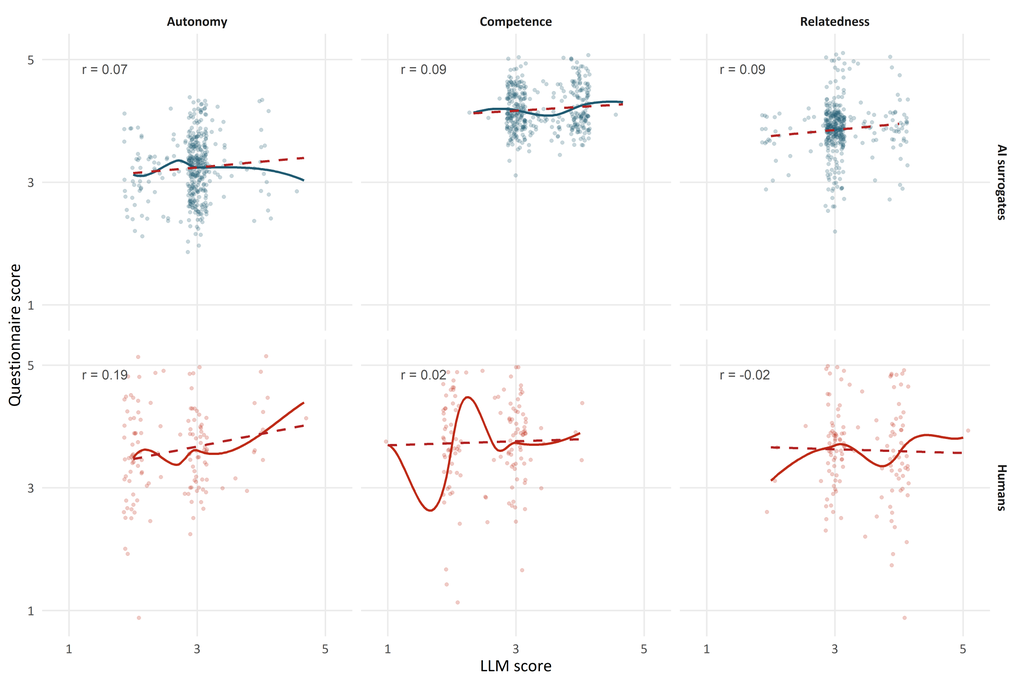

# 7 RQ3a — Distributional Equivalence of LLM Scores

RQ3a tests whether AI surrogate and human participant LLM scores differ in means and variance. Welch’s t-test (unequal variances) and the standard t-test (equal variances assumed) are both reported to assess sensitivity to the variance assumption. Levene’s test (mean-centered) checks whether variances differ between groups. The primary effect size measure is the raw mean difference Δ = M_AI − M_human with 95% bootstrapped CI, preferred over standardized d because a high Cohen’s d with low SD would itself indicate a distributional problem rather than a meaningful effect (Analytical Strategy v2026-03-24). Three tests are run (one per need dimension). These are treated as independent per-dimension questions rather than as a family requiring correction; each need dimension constitutes a separate hypothesis (RQ3a) and the study is exploratory. Accordingly, no family-wise correction is applied.

## 7.1 Welch t-Test, Standard t-Test, Levene Test, and Bootstrapped Δ

Table 8: Mean and SD of LLM Scores by Need Dimension and Group (RQ3a: Distributional Equivalence)

| Need | M (AI) | SD (AI) | M (Human) | SD (Human) | ΔM | ΔSD |
| --- | --- | --- | --- | --- | --- | --- |
| Autonomy | 2.94 | 0.40 | 2.66 | 0.64 | 0.27 | -0.24 |
| Competence | 3.41 | 0.47 | 2.58 | 0.55 | 0.82 | -0.08 |
| Relatedness | 3.07 | 0.40 | 3.42 | 0.54 | -0.35 | -0.14 |

Note. LLM scores on a 1–5 scale. ΔM = M(AI) − M(Human); ΔSD = SD(AI) − SD(Human). Positive ΔSD indicates AI surrogates have higher variance. AI surrogates N = 394; Humans N = 132.

Table 9: Mean and Variance Differences in LLM Scores Between AI Surrogates and Human Participants with Welch’s t-Test and Levene’s Variance Test (RQ3a)

| Need | ΔM [95% CI] | ΔSD [95% CI] | Welch t(df) | p (Welch) | Standard t(df) | p (std.) | Levene F(df₁,df₂) | p (Levene) |
| --- | --- | --- | --- | --- | --- | --- | --- | --- |
| Autonomy | 0.27 [0.16, 0.39] | -0.24 [-0.33, -0.16] | 4.58 (165.9) | < .001 | 5.75 (524.0) | < .001 | 102.28(1,524) | < .001 |
| Competence | 0.82 [0.72, 0.92] | -0.08 [-0.14, -0.02] | 15.44 (199.2) | < .001 | 16.68 (524.0) | < .001 | 10.68(1,524) | 0.001 |
| Relatedness | -0.35 [-0.45, -0.25] | -0.14 [-0.21, -0.07] | -6.73 (181.5) | < .001 | -7.79 (524.0) | < .001 | 75.38(1,524) | < .001 |

Note. ΔM = M_AI − M_Human; ΔSD = SD_AI − SD_Human. CIs: 95% bootstrap percentile (R = 10000, stratified by group). Welch's t-test does not assume equal variances; both versions reported for sensitivity. Levene's test (mean-centered): p < .05 indicates unequal variances. If Welch and standard t diverge substantially, Levene p < .05 indicates variance drives the difference.

## 7.2 Means and SDs bootstrapped

Figure 13: Mean LLM scores by need dimension and group (RQ3a). Bars = observed mean; error bars = ±1 SD.

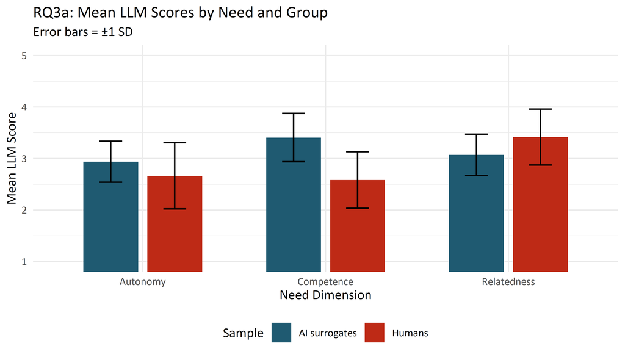

### Means and SDs — shaded CIs

Figure 14: Mean LLM scores by need dimension and group (RQ3a). Error bars = 95% bootstrap CIs. Yellow bracket = Δ mean (AI − Human).

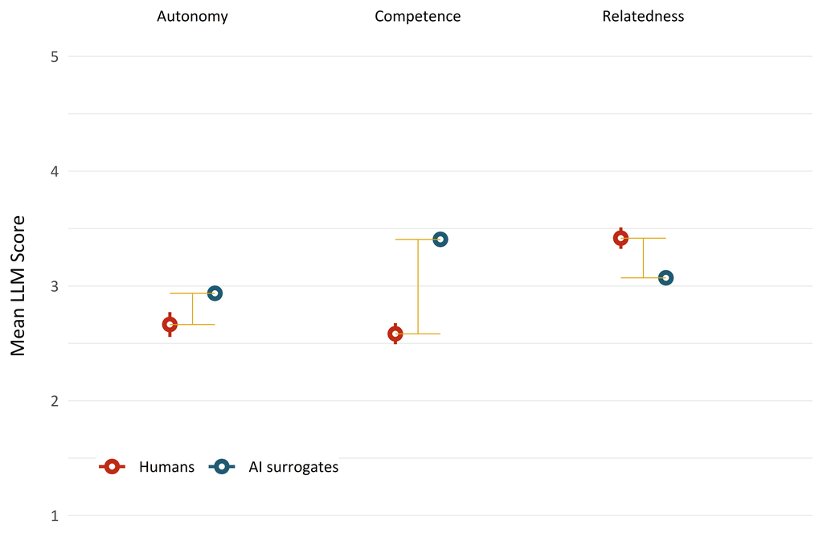

*Note.* Error bars = 95% bootstrap CIs (R = 10^{4}). AI surrogates N = 394; Humans N = 132. Yellow bracket = Δ mean (AI − Human).

Figure 15: SD of LLM scores by need dimension and group (RQ3a). Error bars = 95% bootstrap CIs. Yellow bracket = Δ SD (AI − Human).

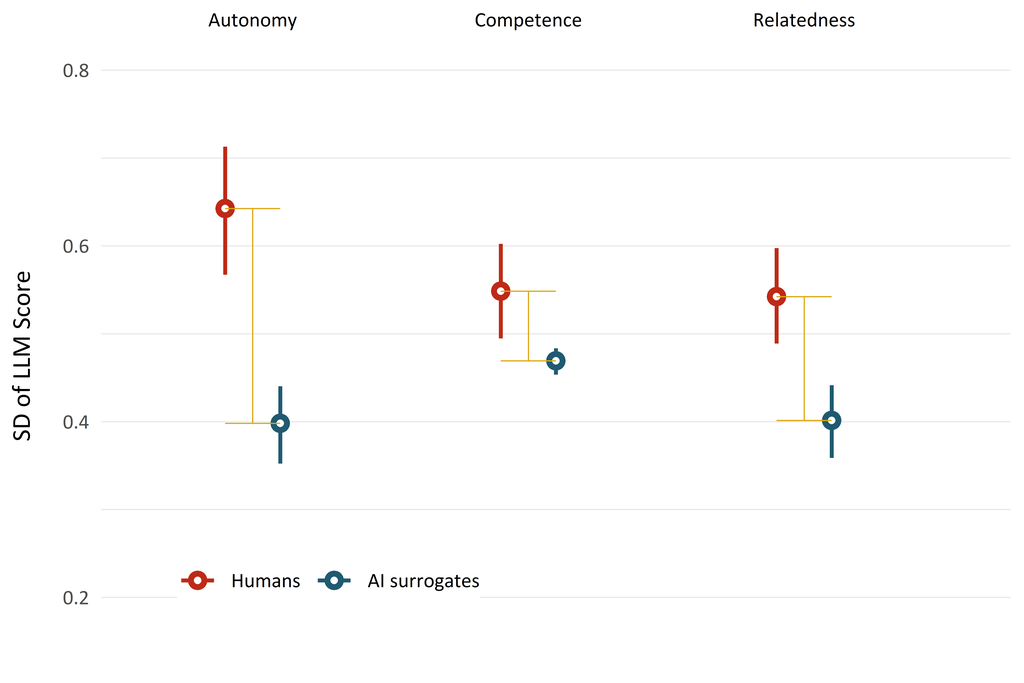

*Note.* Error bars = 95% bootstrap CIs (R = 10^{4}). AI surrogates N = 394; Humans N = 132. Yellow bracket = Δ SD (AI − Human).

# 8 RQ3b — Difference in LLM–Questionnaire Correlations

## 8.1 Preparation

### 8.1.1 Compute Pearson r and Spearman ρ

### 8.1.2 Fisher z-Difference Test

Fisher’s z-difference test (`psych::r.test`) compares Pearson r values across two independent groups. The function applies the Fisher r-to-z transformation internally (z = 0.5 × ln((1+r)/(1-r))). This transformation is required because raw Pearson r values are not normally distributed — they are bounded [−1, 1] and right-skewed near ±1; the transformation normalizes the distribution, enabling a valid z-test. The parameter names `r12` and `r34` are `psych`’s internal naming convention for “group 1 correlation” and “group 2 correlation” — not meaningful variable names.

## 8.2 RQ3b Results Table

Table 10: Pearson Correlations Between LLM and Questionnaire Scores by Group and Fisher z-Difference Test (RQ3b)

| Need Dimension | Humans r [95% CI] | AI surrogates r [95% CI] | Difference Δr [95% CI] | Z | p |
| --- | --- | --- | --- | --- | --- |
| Autonomy | 0.19 [0.02, 0.34] | 0.07 [-0.03, 0.17] | -0.11 [-0.29, 0.08] | 1.11 | 0.267 |
| Competence | 0.02 [-0.14, 0.18] | 0.09 [-0.01, 0.18] | 0.06 [-0.12, 0.25] | 0.60 | 0.547 |
| Relatedness | -0.02 [-0.19, 0.15] | 0.09 [0.00, 0.19] | 0.12 [-0.08, 0.31] | 1.16 | 0.247 |

Note. r = Pearson correlation between LLM score (mean of 3 repeats) and questionnaire score. CIs: 95% bootstrap percentile (R = 10000). Δr = r(AI surrogates) − r(Humans); CI for Δr bootstrapped stratified by group. Z and p from Fisher’s z-difference test for independent correlations (psych::r.test). AI surrogates N = 394; Humans N = 132.

### 8.2.1 Correlation Estimates with SE

The bootstrap percentile method takes the 2.5th and 97.5th percentiles of the bootstrap distribution directly, rather than constructing a symmetric interval around the estimate using ±1.96 × SE. These two approaches only agree when the bootstrap distribution is perfectly normal and symmetric.

Table 11: Pearson Correlations Between LLM and Questionnaire Scores with Bootstrapped SE by Group (RQ3b)

| Need Dimension | Humans r [95% CI] | Humans SE | AI surrogates r [95% CI] | AI surrogates SE | Difference Δr [95% CI] | Difference SE |
| --- | --- | --- | --- | --- | --- | --- |
| Autonomy | 0.19 [0.02, 0.34] | 0.082 | 0.07 [-0.03, 0.17] | 0.051 | -0.11 [-0.29, 0.08] | 0.096 |
| Competence | 0.02 [-0.14, 0.18] | 0.080 | 0.09 [-0.01, 0.18] | 0.051 | 0.06 [-0.12, 0.25] | 0.095 |
| Relatedness | -0.02 [-0.19, 0.15] | 0.085 | 0.09 [0.00, 0.19] | 0.048 | 0.12 [-0.08, 0.31] | 0.098 |

Note. r = Pearson correlation between LLM score (mean of 3 repeats) and questionnaire score. SE = standard deviation of the bootstrap distribution (R = 10000). CIs: 95% bootstrap percentile. Δr = r(AI surrogates) − r(Humans); SE for Δr bootstrapped stratified by group. AI surrogates N = 394; Humans N = 132.

The SEs look modest in absolute terms because correlations are bounded in [−1, +1]. However, they are not small relative to the estimates — they’re actually large relative to the effect sizes, which are themselves near zero. Since r is so small, r is approximately normally distributed — that’s why the standard formula ±1.96 results in the same CI as the bootstrapped percentiles.

### 8.3 Fisher Transformation Visualization

The plot below shows the bootstrap distribution of raw Pearson r (left column) and Fisher z-transformed values (right column) for each need dimension (rows) and group. Raw r is bounded to [−1, 1] and may be skewed when correlations are moderate to strong; the Fisher z-transformation yields approximately symmetric distributions, which is the assumption required by the z-difference test. For correlations near zero, this approximates to z ≈ r — the two are nearly identical numerically.

Figure 16: Bootstrap distributions of raw Pearson r (left) and Fisher z-transformed values (right) by need dimension and group. The z-transformation yields approximately symmetric distributions, satisfying the normality assumption required for the z-test.

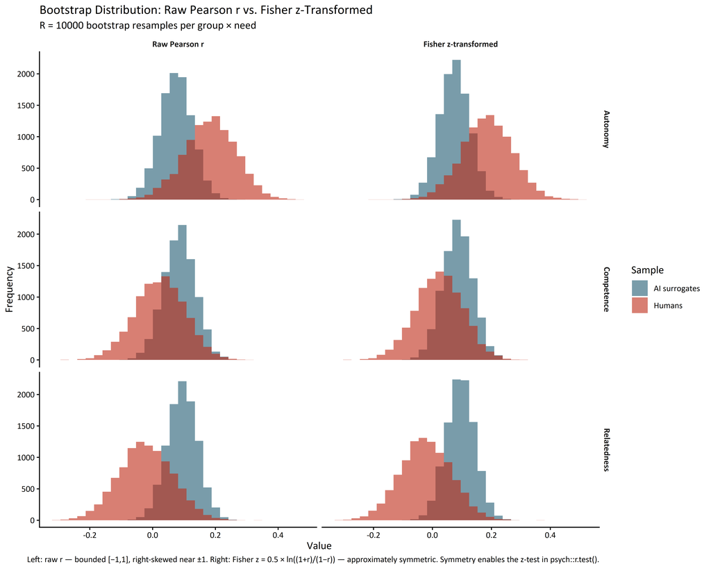

### 8.4 Pearson vs Spearman check

Table 12: Pearson r and Spearman ρ Between LLM Scores and Questionnaire Scores by Need Dimension and Group (RQ3b)

| Need | r (AI) [95% CI] | ρ (AI) | r (Human) [95% CI] | ρ (Human) |
| --- | --- | --- | --- | --- |
| Autonomy | 0.07 [-0.03, 0.17] | 0.06 | 0.19 [0.02, 0.34] | 0.14 |
| Competence | 0.09 [-0.01, 0.18] | 0.05 | 0.02 [-0.14, 0.18] | 0.00 |
| Relatedness | 0.09 [0.00, 0.19] | 0.12 | -0.02 [-0.19, 0.15] | -0.01 |

Note. r = Pearson correlation; ρ = Spearman (robustness check). CIs: 95% bootstrap percentile (R = 10000). AI surrogates N = 394; Humans N = 132.

## 8.5 Visualisation

### 8.5.1 Correlations per group

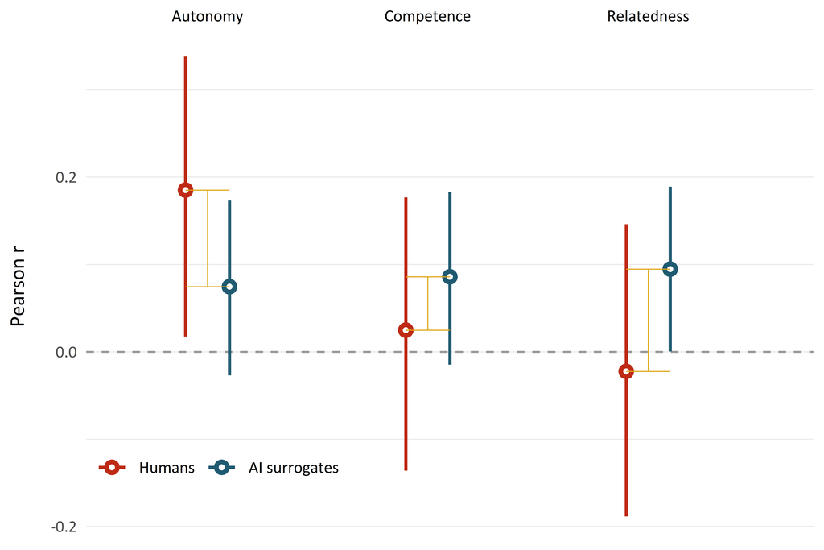

Figure 18: Pearson r between LLM scores and questionnaire scores by need dimension and group (RQ3b). Error bars = 95% bootstrap CIs. Shaded rectangles = difference between point estimates (Δr).

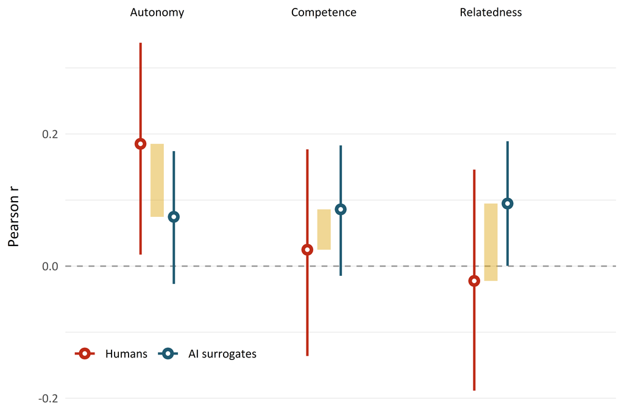

*Note.* Error bars = 95% bootstrap CIs (R = 10^{4}). Shaded rectangles = difference between point estimates (Δr = r_AI − r_Human). AI surrogates N = 394; Humans N = 132.

### 8.5.2 Δr from Fisher’s z-difference test

Figure 19: Δr (r_AI − r_Human) per need dimension with 95% bootstrap CIs (RQ3b). Dashed line = 0 (no group difference). Points above zero indicate stronger LLM–questionnaire correspondence in AI surrogates than humans.

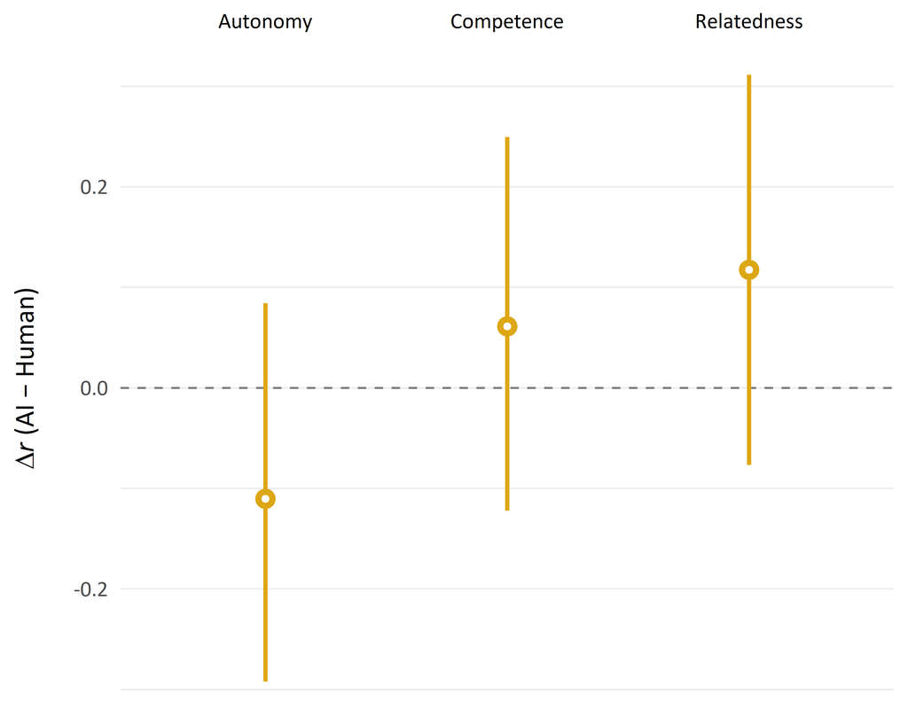

*Note.* Δr = r(AI surrogates) − r(Humans). Error bars = 95% bootstrap CIs for Δr (R = 10^{4}, stratified by group). Z and p from Fisher’s z-difference test; see Table 10.

# 9 Sensitivity: Equal-Width Binning of LLM Scores

LLM score means are continuous averages of three repeated scorings on a 1–5 integer scale. This section applies equal-width binning by rounding each mean to the nearest integer ($3.1 \to 3$, $3.6 \to 4$), collapsing the continuous distribution back onto the five integer bins. Correlations between binned LLM scores and questionnaire scores are then recomputed for both groups and compared to the unrounded results in Table 10. All code is self-contained and does not modify any upstream objects.

## 9.1 Histogram of Rounded LLM Scores

Figure 20: Frequency distributions of LLM scores after rounding to the nearest integer (equal-width binning, bin width = 1), by need dimension and sample group. Vertical lines indicate group means of the rounded scores. Compare with the unrounded distributions in Figure 3.

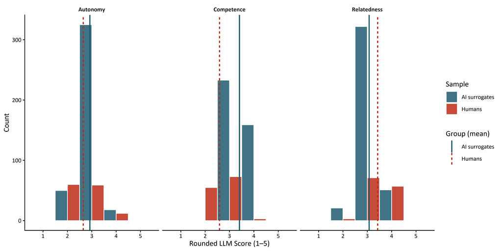

## 9.2 Correlations with Rounded LLM Scores

Table 13: Pearson Correlations Between Rounded LLM Scores and Questionnaire Scores by Need Dimension and Group (Equal-Width Binning Sensitivity Check)

| Need | Humans | Humans Δr | AI surrogates | AI surrogates Δr |
| --- | --- | --- | --- | --- |
| Autonomy | 0.17 | -0.02 | 0.07 | 0.00 |
| Competence | 0.01 | -0.01 | 0.09 | 0.00 |
| Relatedness | -0.04 | -0.02 | 0.07 | -0.02 |

Note. LLM scores rounded to the nearest integer before correlation (e.g., 3.1 → 3, 3.6 → 4). Questionnaire scores are unmodified means. Δr = r(rounded) − r(unrounded); reference values from @tbl-rq3b-fisher-zdiff. AI surrogates N = 394; Humans N = 132.

## 9.3 Histogram of Rounded Questionnaire Scores

Figure 21: Frequency distributions of questionnaire scores after rounding composite means to the nearest integer (equal-width binning, bin width = 1), by need dimension and sample group. Vertical lines indicate group means of the rounded scores. Compare with the unrounded distributions in Figure 3.

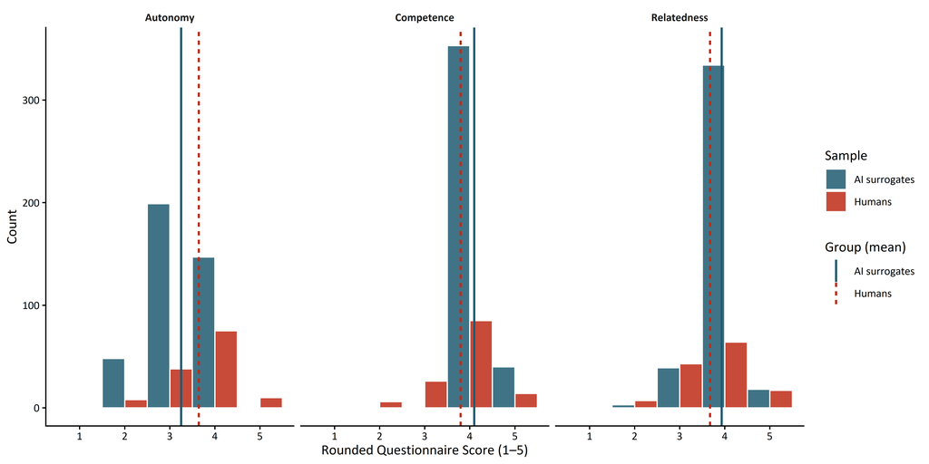

## 9.4 Correlations: Rounded LLM Scores × Rounded Questionnaire Scores

Table 14: Pearson Correlations Between Rounded LLM Scores and Rounded Questionnaire Scores by Need Dimension and Group (Both Variables Binned — Equal-Width Sensitivity Check)

| Need | Humans | Humans Δr | AI surrogates | AI surrogates Δr |
| --- | --- | --- | --- | --- |
| Autonomy | 0.16 | -0.03 | 0.04 | -0.03 |
| Competence | -0.02 | -0.04 | 0.15 | 0.06 |
| Relatedness | -0.08 | -0.06 | 0.04 | -0.05 |

Note. Both LLM scores and questionnaire scores rounded to the nearest integer before correlation (e.g., 3.1 → 3, 3.6 → 4). Δr = r(both rounded) − r(unrounded); reference values from @tbl-rq3b-fisher-zdiff. AI surrogates N = 394; Humans N = 132.

## 9.5 Competence Cross-Tabulation (Rounded LLM × Rounded Questionnaire)

Table 15: Cross-Tabulation of Rounded LLM Competence and Rounded Questionnaire Competence — AI Surrogates

| LLM Competence (rounded) | Questionnaire Competence (rounded) 1 | Questionnaire Competence (rounded) 2 | Questionnaire Competence (rounded) 3 | Questionnaire Competence (rounded) 4 | Questionnaire Competence (rounded) 5 |
| --- | --- | --- | --- | --- | --- |
| 1 | 0 | 0 | 0 | 0 | 0 |
| 2 | 0 | 0 | 0 | 1 | 0 |
| 3 | 0 | 0 | 1 | 217 | 15 |
| 4 | 0 | 0 | 0 | 134 | 25 |
| 5 | 0 | 0 | 0 | 1 | 0 |

Note. Rows = rounded LLM Competence (1–5); columns = rounded questionnaire Competence (1–5). Cell entries are counts. AI surrogates N = 394.

Table 16: Cross-Tabulation of Rounded LLM Competence and Rounded Questionnaire Competence — Human Participants

| LLM Competence (rounded) | Questionnaire Competence (rounded) 1 | Questionnaire Competence (rounded) 2 | Questionnaire Competence (rounded) 3 | Questionnaire Competence (rounded) 4 | Questionnaire Competence (rounded) 5 |
| --- | --- | --- | --- | --- | --- |
| 1 | 0 | 0 | 0 | 1 | 0 |
| 2 | 1 | 3 | 10 | 32 | 9 |
| 3 | 0 | 3 | 16 | 49 | 5 |
| 4 | 0 | 0 | 0 | 3 | 0 |
| 5 | 0 | 0 | 0 | 0 | 0 |

Note. Rows = rounded LLM Competence (1–5); columns = rounded questionnaire Competence (1–5). Cell entries are counts. Humans N = 132.

# 10 Sensitivity: Polychoric Correlations on Rounded Scores

Polychoric correlation treats both variables as ordinal (discretized underlying latent continua), which is more appropriate than Pearson r when scores are rounded integers on a 1–5 scale. Both LLM and questionnaire scores are rounded to the nearest integer (same rounding as Section 9) before computing polychoric r. The 95% CIs are bootstrap percentile (R = 1,000; polychoric is computationally heavier than Pearson so a smaller B is used here). Δr shows the difference from the unrounded Pearson r in Table 10.

Table 17: Polychoric Correlations Between Rounded LLM and Questionnaire Scores by Need Dimension and Group (Ordinal Sensitivity Check)

| Need Dimension | Humans r_poly [95% CI] | Humans Δr | AI surrogates r_poly [95% CI] | AI surrogates Δr |
| --- | --- | --- | --- | --- |
| Autonomy | 0.19 [-0.05, 0.37] | 0.01 | 0.05 [-0.09, 0.19] | -0.02 |
| Competence | -0.04 [-0.25, 0.11] | -0.07 | 0.30 [0.10, 0.47] | 0.22 |
| Relatedness | -0.08 [-0.26, 0.12] | -0.06 | 0.07 [-0.08, 0.22] | -0.03 |

Note. Polychoric correlation between LLM score and questionnaire score, both rounded to the nearest integer (same rounding as Section 9). 95% CIs: bootstrap percentile (R = 1000). Δr = r_poly − r_Pearson (unrounded, from @tbl-rq3b-fisher-zdiff). AI surrogates N = 394; Humans N = 132.

# 11 Summary: Pearson, Spearman, and Polychoric Correlations

Table 18: LLM–Questionnaire Correlations by Method, Need Dimension, and Group

| Need Dimension | Humans Pearson r | Humans Spearman ρ | Humans Polychoric r | AI surrogates Pearson r | AI surrogates Spearman ρ | AI surrogates Polychoric r |
| --- | --- | --- | --- | --- | --- | --- |
| Autonomy | 0.19 [0.02, 0.34] | 0.14 [-0.03, 0.31] | 0.19 [-0.04, 0.38] | 0.07 [-0.03, 0.17] | 0.06 [-0.04, 0.16] | 0.05 [-0.10, 0.19] |
| Competence | 0.02 [-0.14, 0.18] | -0.00 [-0.16, 0.17] | -0.04 [-0.25, 0.11] | 0.09 [-0.01, 0.18] | 0.05 [-0.05, 0.15] | 0.30 [0.10, 0.47] |
| Relatedness | -0.02 [-0.19, 0.15] | -0.01 [-0.19, 0.16] | -0.08 [-0.28, 0.14] | 0.09 [0.00, 0.19] | 0.12 [0.02, 0.21] | 0.07 [-0.07, 0.23] |

Note. All values shown as r [95% CI]. Pearson r and Spearman ρ computed on unrounded continuous scores; Pearson CIs: bootstrap percentile (R = 10000); Spearman CIs: bootstrap percentile (R = 10000). Polychoric r computed on rounded integer scores; CIs: bootstrap percentile (R = 1000). AI surrogates N = 394; Humans N = 132.

Figure 22: LLM–questionnaire correlations by method, need dimension, and group. Error bars = 95% bootstrap CIs. Yellow bracket = Δr (AI − Human). Pearson and Spearman on unrounded scores; Polychoric on rounded integer scores.

[figure not shown]

*Note.* Error bars = 95% bootstrap CIs. Pearson and Spearman: R = 10^{4}; Polychoric: R = 1000. AI surrogates N = 394; Humans N = 132. Yellow bracket = Δr (AI − Human).

# 12 Sensitivity: Actual Word Count as a Comparability Covariate

The matched AI condition (three texts, ~150-word target) approximates the human sample’s average total word count. However, human participants wrote Swedish texts with a wider and generally higher distribution of actual word counts compared to the tightly constrained English AI texts. If LLM scores are sensitive to raw text length, between-group differences in Sections 7 and 8 may partly reflect this mismatch.

First, word count distributions are visualised for both groups (expanding Section 3.6).

Second, within-group regressions of each LLM score on `actual_words` are reported separately per group and need dimension. If the slopes and R² values are near zero, word count does not appreciably drive LLM scores within either group, and the between-group comparison is not confounded by the word count gap. Third, partial correlations for RQ3b partial out `actual_words` before assessing LLM–questionnaire correspondence.

## 12.1 Word Count Distributions by Group

Figure 23: Distribution of actual word counts (total across scored texts) for AI surrogates and human participants. Vertical lines indicate group medians. The difference in location and spread reflects that human texts were unconstrained and written in Swedish, while AI surrogate texts were constrained to a target length in English.

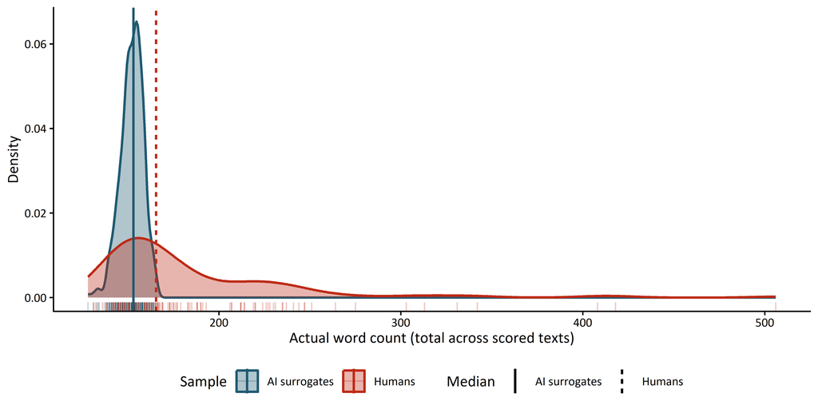

## 12.2 RQ3a Sensitivity: Within-Group Regression of LLM Scores on Word Count

For each group and need dimension, a simple linear regression predicts the LLM score from `actual_words`. A near-zero slope and low R² indicate that word count does not drive LLM scores within that group; the between-group comparison in Section 7 is then not confounded by the word count gap.

Table 19: Within-Group Regression of LLM Scores on Actual Word Count by Need Dimension (RQ3a Word Count Sensitivity)

| Need | AI surrogates b (AI) | AI surrogates SE (AI) | AI surrogates p (AI) | AI surrogates R² (AI) | Humans b (Human) | Humans SE (Human) | Humans p (Human) | Humans R² (Human) |
| --- | --- | --- | --- | --- | --- | --- | --- | --- |
| Autonomy | -0.0031 | 0.0032 | 0.345 | 0.002 | 0.0012 | 0.0010 | 0.226 | 0.011 |
| Competence | 0.0000 | 0.0038 | 0.990 | 0.000 | 0.0019 | 0.0008 | 0.020 | 0.041 |
| Relatedness | 0.0052 | 0.0033 | 0.111 | 0.006 | 0.0007 | 0.0008 | 0.393 | 0.006 |

Note. OLS regression: LLM score ~ actual_words, fitted separately within each group. b = unstandardized slope (change in LLM score per additional word). R² = proportion of variance in LLM score explained by word count within that group. Near-zero b and R² indicate word count does not drive LLM scores within the group. AI surrogates N = 394; Humans N = 132.

## 12.3 RQ3b Sensitivity: Partial Correlations Controlling for Word Count

Within each group, both the LLM score and the questionnaire score are regressed on `actual_words`; the partial correlation is computed on the residuals. Specifically, both variables are individually regressed on `actual_words` via OLS; the Pearson correlation of the two residual vectors is then taken. This residualization approach is equivalent to a formal partial correlation when both regressions share the same single covariate and OLS is used — the values are numerically identical. This removes variance attributable to text length from both measures before assessing their correspondence. Bootstrap CIs use the same stratified resampling as Section 8.

Table 20: Partial Correlations Between LLM Scores and Questionnaire Scores Controlling for Actual Word Count by Need Dimension and Group (RQ3b Word Count Sensitivity)

| Need | Humans pr [95% CI] | Humans Δr | AI surrogates pr [95% CI] | AI surrogates Δr |
| --- | --- | --- | --- | --- |
| Autonomy | 0.19 [0.02, 0.34] | 0.01 | 0.07 [-0.03, 0.17] | -0.00 |
| Competence | 0.02 [-0.15, 0.17] | -0.01 | 0.09 [-0.01, 0.18] | 0.00 |
| Relatedness | -0.03 [-0.20, 0.14] | -0.01 | 0.10 [0.01, 0.19] | 0.01 |

Note. pr = partial Pearson correlation between LLM score and questionnaire score, with actual word count partialled out via residualization within each group. CIs: 95% bootstrap percentile (R = 10000). Δr = pr − r(unrounded Pearson); reference values from @tbl-rq3b-fisher-zdiff. Positive Δr indicates the partial correlation exceeds the raw correlation (word count suppressed the association); negative Δr indicates word count inflated the raw correlation. AI surrogates N = 394; Humans N = 132.

Figure 24: Partial Pearson correlations (controlling for actual word count) between LLM scores and questionnaire scores by need dimension and group (RQ3b). Open symbols with error bars = partial r (this section); filled symbols = raw Pearson r from Table 10 for reference. Error bars = 95% bootstrap CIs for partial r.

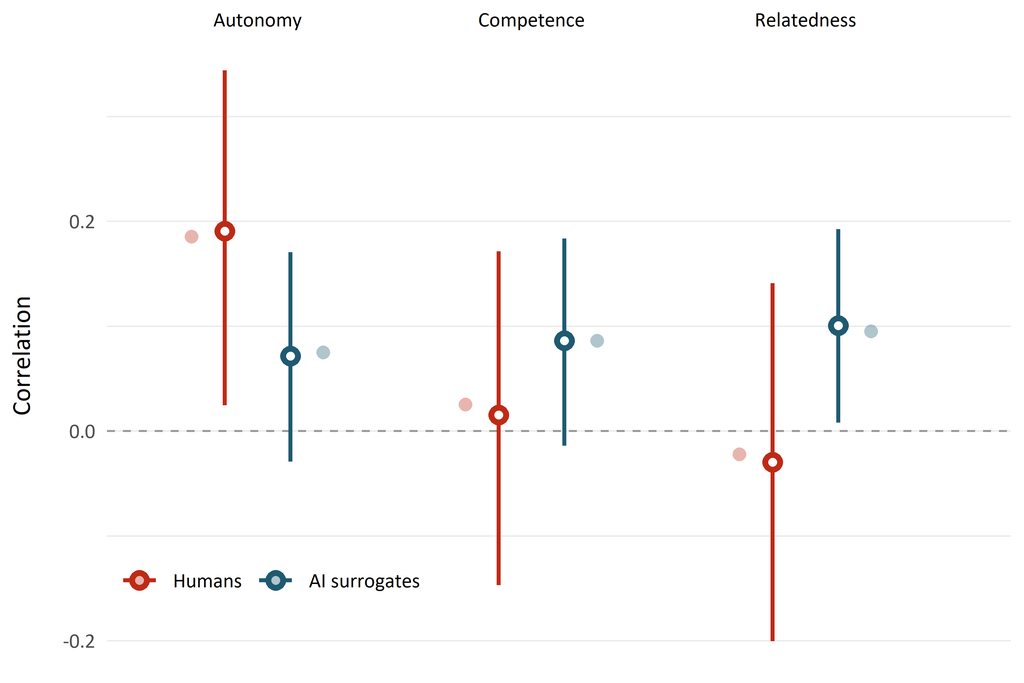

*Note.* Open symbols with error bars = partial r [95% bootstrap CI, R = 10^{4}]. Filled symbols = raw Pearson r from Table 10 (no CI shown). AI surrogates N = 394; Humans N = 132.